# Génération de labyrtinthes et recherche de solution

## Le but est de trouver le plus court chemin dans un labyrinthe en utilisant l'algorithme de Dijkstra

On va tout d'abord chercher à générer nos propres labyrinthes pour tester l'algorithme

Ce seront des labyrinthes carrés ou du moins rectangulaires dans un premier temps, pour des raisons pratiques et esthétiques.

On testera dans un second temps sur des labyrinthes plus exotiques afin de vérifier l'exactitude et l'universalité de notre implémentation de l'algorithme de Dijkstra

```python
import random
from enum import Enum
import numpy as np
import sys
from PIL import Image
from IPython import display
import matplotlib.pyplot as plt
inf8 = float('inf')
```

```python
sys.setrecursionlimit(8000)
class Directions(Enum):
    UP = 1
    DOWN = 2
    LEFT = 3
    RIGHT = 4

def createMaze(width,height):

    #On élargit le labyrinthe pour pouvoir entourer de murs
    if width % 2 == 0:
        width += 1
    if height % 2 == 0:
        height += 1

    maze = np.ones((height, width),dtype=float)

    for i in range(height):
        for j in range(width):
            if i % 2 == 1 or j % 2 == 1:
                maze[i, j] = 0
                if i == 0 or j == 0 or i == height - 1 or j == width - 1:
                    maze[i, j] = 0.5

    sx = random.choice(range(2, width - 2, 2))
    sy = random.choice(range(2, height - 2, 2))

    generator(sx, sy, maze, width, height)

    for i in range(height):
        for j in range(width):
            if maze[i, j] == 0.5:
                maze[i, j] = 1

    maze[1, 2] = 1
    maze[height - 2, width - 3] = 1

    maze = maze * 255.0
    im = Image.fromarray(maze)
    im=im.convert("L")
    im.save("maze.png")
    plt.imshow(im)

    return maze

def generator(cx, cy, grid, width, height):
    grid[cy, cx] = 0.5
    #on se restreint bien a la zone de travail pour eviter les erreurs d'indice
    if not (cx in range(2, width - 2) and cy in range(2, height - 2)):
        pass
    elif grid[cy - 2, cx] == 0.5 and grid[cy + 2, cx] == 0.5 and grid[cy, cx - 2] == 0.5 and grid[cy, cx + 2] == 0.5:
        pass
    else:
        li = [1, 2, 3, 4]
        while len(li) > 0:
            dir = random.choice(li)
            li.remove(dir)

            if dir == Directions.UP.value:
                ny = cy - 2
                my = cy - 1
            elif dir == Directions.DOWN.value:
                ny = cy + 2
                my = cy + 1
            else:
                ny = cy
                my = cy

            if dir == Directions.LEFT.value:
                nx = cx - 2
                mx = cx - 1
            elif dir == Directions.RIGHT.value:
                nx = cx + 2
                mx = cx + 1
            else:
                nx = cx
                mx = cx

            if grid[ny, nx] != 0.5:
                grid[my, mx] = 0.5
                generator(nx, ny, grid, width, height)
```

```
array([[255., 255., 255., ..., 255., 255., 255.],
       [255.,   0., 255., ..., 255.,   0., 255.],
       [255., 255., 255., ..., 255., 255., 255.],
       ...,
       [255., 255., 255., ..., 255., 255., 255.],
       [255.,   0., 255., ..., 255.,   0., 255.],
       [255., 255., 255., ..., 255., 255., 255.]])
```

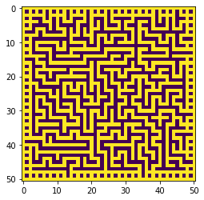

```python
createMaze(50,50)
```

On peut voir qu'il y a des soucis sur les bords, nos labyrinthes sont résolubles de façon triviale : en passant par les bords ! On va donc modifier le code pour nettoyer le rendu

```python
sys.setrecursionlimit(8000)
class Directions(Enum):
    UP = 1
    DOWN = 2
    LEFT = 3
    RIGHT = 4

def createMaze(width,height,name):

    #On élargit le labyrinthe pour pouvoir entourer de murs
    if width % 2 == 0:
        width += 1
    if height % 2 == 0:
        height += 1

    #Ici on elargit la zone de travail, On terminera par elaguer afin d'obtenir un joli labyrinthe
    width+=2
    height+=2

    maze = np.ones((height, width),dtype=float)

    for i in range(height):
        for j in range(width):
            if i % 2 == 1 or j % 2 == 1:
                maze[i, j] = 0
                if i == 0 or j == 0 or i == height - 1 or j == width - 1:
                    maze[i, j] = 0.5

    sx = random.choice(range(2, width - 2, 2))
    sy = random.choice(range(2, height - 2, 2))

    generator(sx, sy, maze, width, height)

    for i in range(height):
        for j in range(width):
            if maze[i, j] == 0.5:
                maze[i, j] = 1

    maze[1, 2] = 1
    maze[height - 2, width - 3] = 1

    maze = maze * 255.0
    #On crop afin d'eliminer les traces de l'algorithme sur les bords
    final=maze[2:-2,2:-2]
    im = Image.fromarray(final)
    im=im.convert("L")
    im.save(name + '.png')
    plt.imshow(im)

    return final

def generator(cx, cy, grid, width, height):
    grid[cy, cx] = 0.5
    #on se restreint bien a la zone de travail pour eviter les erreurs d'indice
    if not (cx in range(2, width - 2) and cy in range(2, height - 2)):
        pass
    elif grid[cy - 2, cx] == 0.5 and grid[cy + 2, cx] == 0.5 and grid[cy, cx - 2] == 0.5 and grid[cy, cx + 2] == 0.5:
        pass
    else:
        li = [1, 2, 3, 4]
        while len(li) > 0:
            dir = random.choice(li)
            li.remove(dir)

            if dir == Directions.UP.value:
                ny = cy - 2
                my = cy - 1
            elif dir == Directions.DOWN.value:
                ny = cy + 2
                my = cy + 1
            else:
                ny = cy
                my = cy

            if dir == Directions.LEFT.value:
                nx = cx - 2
                mx = cx - 1
            elif dir == Directions.RIGHT.value:
                nx = cx + 2
                mx = cx + 1
            else:
                nx = cx
                mx = cx

            if grid[ny, nx] != 0.5:
                grid[my, mx] = 0.5
                generator(nx, ny, grid, width, height)
```

```
array([[255.,   0., 255., ..., 255.,   0., 255.],
       [255.,   0., 255., ..., 255.,   0., 255.],
       [255.,   0., 255., ..., 255.,   0., 255.],
       ...,
       [255.,   0., 255., ..., 255.,   0., 255.],
       [255.,   0.,   0., ...,   0.,   0., 255.],
       [255., 255., 255., ..., 255., 255., 255.]])
```

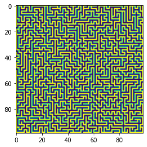

```python
createMaze(100,100,'maze2')
```

[figure not shown]

On va maintenant passer à la résolution des labyrinthes générés, en utilisant l'algorithme de Dijkstra https://en.wikipedia.org/wiki/Dijkstra%27s_algorithm

On commence par créer quelques fonctions auxiliaires

```python
def dijkstra_init(graph, source = (0,0)):
    d=np.zeros(graph.shape)
    prev=np.empty(graph.shape,tuple)
    Q=[]
    for i in range(graph.shape[0]):
        for j in range(graph.shape[1]):
            d[i,j]=inf8
            Q.append((i,j))
    d[source]=0
    return d,prev,Q

#Ici on s'intéresse aux changements de couleur
#La distance entre un point noir et un point blanc doit être prohibitive

def dist(m,a,b=(0,0)):
    return abs(m[b]-m[a])/255

def dijkstra_get_min(Q, d):
    m=inf8
    u=(-1,-1)
    for s in Q:
        if d[s] < m:
            m = d[s]
            u = s
    return u

def neighbours(node):
    x, y = node
    return [
        (x + x_offset, y + y_offset)
        for x_offset in (-1, 0, 1)
        for y_offset in (-1, 0, 1)
        if  not(x_offset == y_offset == 0) and (x_offset ==0 or y_offset == 0) # on bloque la case en elle meme

    ]
```

```python
def dijkstra(graph, source=(0,0)):
    d,prev,Q=dijkstra_init(graph, source)
    while Q:
        u= dijkstra_get_min(Q,d)
        Q.remove(u)
        for v in neighbours(u):
            if 0<=v[0]<graph.shape[0] and 0<=v[1]<graph.shape[1]:
                if d[v] > (d[u]+dist(graph,v,u)):
                    d[v] = (d[u]+dist(graph,v,u))
                    prev[v] = u
    return d, prev
```

```
(array([[0., 1., 0., ..., 0., 0., 0.],
        [0., 1., 0., ..., 1., 1., 1.],
        [0., 1., 0., ..., 0., 0., 0.],
        ...,
        [0., 0., 0., ..., 0., 0., 0.],
        [1., 1., 1., ..., 0., 1., 0.],
        [0., 0., 0., ..., 0., 1., 0.]]),
 array([[None, (0, 0), (1, 2), ..., (0, 45), (0, 46), (0, 47)],
        [(0, 0), (1, 0), (2, 2), ..., (2, 46), (2, 47), (2, 48)],
        [(1, 0), (2, 0), (2, 3), ..., (2, 47), (2, 48), (3, 48)],
        ...,
        [(45, 0), (46, 0), (46, 1), ..., (47, 46), (46, 46), (46, 47)],
        [(46, 0), (46, 1), (46, 2), ..., (48, 46), (47, 46), (46, 48)],
        [(48, 1), (48, 2), (48, 3), ..., (48, 45), (48, 46), (47, 48)]],
       dtype=object))
```

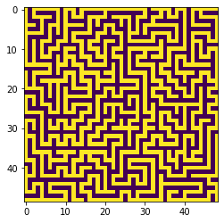

```python
dijkstra(createMaze(50,50,'maze2'),(0,0))
```

On peut alors créer une fonction qui va nous dessiner le chemin trouvé sur le labyrinthe

```python
def dijkstra_path(graph,name='solution',source=(0,0),destination=(-1,-1)):
    path=[]
    prev=dijkstra(graph,source)[1]
    s=destination
    while s!=source:
        path.append(s)
        s=prev[s]
    path.append(source)
    graphint=graph.astype(int)
    for x in path:
        graphint[x]=75
    im= Image.fromarray(graphint)
    im=im.convert("L")
    im.save(name + '.png')
    plt.imshow(im)
```

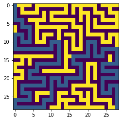

```python
dijkstra_path(createMaze(30,30,'maze2'))
```

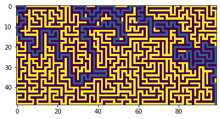

```python
dijkstra_path(createMaze(100,50,'maze3'),'solution2')
```

[figure not shown]

Bien, tout semble fonctionner Essayons maintenant avec un labyrinthe rond, par exemple:

[figure not shown]

Ici l'arrivée est au milieu, on garde le départ en haut à gauche

Il nous faut donc convertir l'image en ndarray pour pouvoir le traiter avec notre programme

```
(240, 241)
```

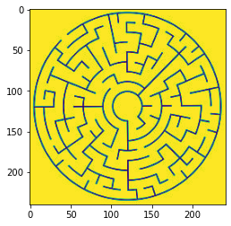

```python
import imageio
img = imageio.imread('https://upload.wikimedia.org/wikipedia/commons/thumb/d/d2/Circularmazeexample.jpg/241px-Circularmazeexample.jpg')
circ1=np.array(img)
print(circ1.shape)
plt.imshow(img)
```

On va traiter l'image pour s'assurer de n'avoir que des pixels blancs ou noirs

```python
circ1[circ1<128]=0
circ1[circ1>=128]=255
```

Je suspecte notre implémentation de Dijkstra d'être sous-optimale, je vais donc minuter la résolution

```
174.63121050000063
```

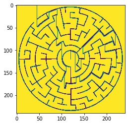

```python
from timeit import default_timer as timer
start=timer()
dijkstra_path(circ1,'test',(0,0),(120,120))
end=timer()
t1=end-start
print(t1)
```

On va procéder à quelques modifications, à savoir:

```
- Modification de la fonction distance car la précédente n'est sensible qu'aux différences de couleur

- Autoriser les diagonales

- Utiliser une liste à priorité pour éviter d'avoir à rechercher le minimum dans Q à chaque itération, optimisation générale du code
```

```python
import math

#Nouvelle distance pseudo euclidienne, sensible aux murs

def dist(m,a,b=(0,0)):
    if(m[a]==m[b]==255):
        d=math.sqrt(abs(b[0]-a[0])**2 + abs(b[1]-a[1])**2)
    else:
        d=inf8
    return d

def neighbours_full(node):
    x, y = node
    return [
        (x + x_offset, y + y_offset)
        for x_offset in (-1, 0, 1)
        for y_offset in (-1, 0, 1)
        if  not(x_offset == y_offset == 0) # on bloque la case en elle meme et sinon on retourne les 8 voisins directs

    ]

from heapq import heappush, heappop

def dijkstra_init_full(graph, source = (0,0)):
    d=np.zeros(graph.shape)
    prev=np.empty(graph.shape,tuple)
    vis=np.empty(graph.shape) #On va utiliser un tableau de booléen pour voir si on a visité la case, pour avoir une
                                #liste de travail réduite
    Q=[]

    for i in range(graph.shape[0]):
        for j in range(graph.shape[1]):
            d[i,j]=inf8
            vis[i,j]=False

    d[source],vis[source]=0,True
    #Contrairement à précédemment, on commence avec une liste contenant seulement la source,
    #au lieu de l'ensemble des sommets
    heappush(Q,(0,source))
    return d,prev,Q,vis

def dijkstra_full(graph, source=(0,0)):
    d,prev,Q,vis=dijkstra_init_full(graph, source)

    while Q:
        (di, u) = heappop(Q)
        vis[u] = True
        for v in neighbours_full(u):
            if (0<=v[0]<graph.shape[0]) and (0<=v[1]<graph.shape[1]) and (not vis[v]) :
                if d[v]> di+dist(graph,v,u):
                    d[v] = di + dist(graph,v,u)
                    heappush(Q, (d[v], v))
                    prev[v] = u
    return d, prev

def dijkstra_path_full(graph,name='solution',source=(0,0),destination=(-1,-1)):
    path=[]
    prev=dijkstra_full(graph,source)[1]
    s=destination

    while s != source:
        path.append(s)
        s=prev[s]

    path.append(source)
    graphint=np.zeros((graph.shape[0],graph.shape[1],3))
    graphint[:,:,0]=graph.astype(int)
    graphint[:,:,1]=graph.astype(int)
    graphint[:,:,2]=graph.astype(int)
    for x in path:
        graphint[x[0],x[1],1]=75 #On s'arrange pour faire ressortir le chemin

    im= Image.fromarray(graphint.astype('uint8'),"RGB")
    #im=im.convert("L")
    im.save(name + '.png')
    plt.imshow(im)
```

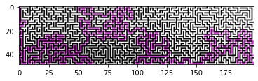

```python
dijkstra_path_full(createMaze(200,50,'maze2'))
```

Comparons les performances avec l'exécution précédente sur le labyrinthe rond

```
194.57293192061658
```

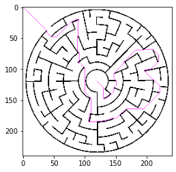

```python
start=timer()
dijkstra_path_full(circ1,'test',(0,0),(120,120))
end=timer()
t2=end-start
print(t1/t2)
```

Le résultat est convaincant

Voulant tester sur de gros labyrinthes générés par notre programme, celui-ci crash dès que la taille des tableaux dépasse 2^15.

Nous allons donc ré-écrire notre fonction génératrice en utilisant un arbre binaire

```python
import numpy as np
def carve_maze_bin(grid:np.ndarray, size:int) -> np.ndarray:
    output_grid = np.empty([size*3, size*3],dtype=int)
    output_grid[:] = 0

    i = 0
    j = 0
    while i < size:
        w = i*3 + 1
        while j < size:
            k = j*3 + 1
            toss = grid[i,j]
            output_grid[w,k] = 255
            if toss == 0 and k+2 < size*3:
                output_grid[w,k+1] = 255
                output_grid[w,k+2] = 255
            if toss == 1 and w-2 >=0:
                output_grid[w-1,k] = 255
                output_grid[w-2,k] = 255

            j = j + 1

        i = i + 1
        j = 0

    return output_grid

def preprocess_grid_bin(grid:np.ndarray, size:int) -> np.ndarray:

    # fix first row and last column to avoid digging outside the maze external borders
    first_row = grid[0]
    first_row[first_row == 1] = 0
    grid[0] = first_row
    for i in range(1,size):
        grid[i,size-1] = 1
    return grid

def gen_bin(n=1, p=0.5, size=5,name='mazebin'):

    grid = np.random.binomial(n,p, size=(size,size))
    processed_grid = preprocess_grid_bin(grid, size)

    maze = carve_maze_bin(processed_grid, size)
    im = Image.fromarray(maze)
    im=im.convert("L")
    im.save(name +'.png')
    plt.imshow(im)
    return maze
```

```
array([[  0,   0,   0, ...,   0,   0,   0],
       [  0, 255, 255, ..., 255, 255,   0],
       [  0, 255,   0, ...,   0, 255,   0],
       ...,
       [  0, 255,   0, ...,   0, 255,   0],
       [  0, 255,   0, ..., 255, 255,   0],
       [  0,   0,   0, ...,   0,   0,   0]])
```

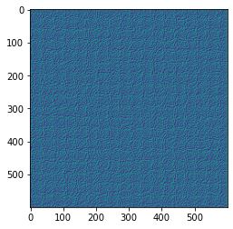

```python
gen_bin(1,0.5,200)
```

[figure not shown]

La génération est rapide mais ces labyrinthes ne sont pas très esthétiques, essayons avec l'algorithme "recursive backtracker"

https://en.wikipedia.org/wiki/Maze_generation_algorithm#Recursive_backtracker

```python
from queue import LifoQueue
from PIL import Image
import numpy as np
from random import choice

def gen_back(w, h):
    width=w//2
    height=h//2
    maze = np.zeros((2*width+1, 2*height+1))

    # Create a path on the very top and bottom so that it has an entrance/exit
    maze[:2,:2] = 255
    maze[-2:, -2:] = 255

    cells = np.zeros((width, height))
    stack = LifoQueue()
    cells[0, 0] = 1
    stack.put((0, 0))

    while not stack.empty():
        x, y = stack.get()

        adjacents = []
        if x > 0 and cells[x - 1, y] == 0:
            adjacents.append((x - 1, y))
        if x < width - 1 and cells[x + 1, y] == 0:
            adjacents.append((x + 1, y))
        if y > 0 and cells[x, y - 1] == 0:
            adjacents.append((x, y - 1))
        if y < height - 1 and cells[x, y + 1] == 0:
            adjacents.append((x, y + 1))

        if adjacents:
            stack.put((x, y))

            neighbour = choice(adjacents)
            neighbour_on_img = (neighbour[0]*2 + 1, neighbour[1]*2 + 1)
            current_on_img = (x*2 + 1, y*2 + 1)
            wall_to_remove = (neighbour[0] + x + 1, neighbour[1] + y + 1)

            maze[neighbour_on_img] = 255
            maze[current_on_img] = 255
            maze[wall_to_remove] = 255

            cells[neighbour] = 1
            stack.put(neighbour)

    im = Image.fromarray(maze)
    im=im.convert("L")
    plt.imshow(im)
    return maze
```

```
array([[255., 255.,   0., ...,   0.,   0.,   0.],
       [255., 255.,   0., ...,   0., 255.,   0.],
       [  0., 255.,   0., ...,   0., 255.,   0.],
       ...,
       [  0.,   0.,   0., ...,   0.,   0.,   0.],
       [  0., 255., 255., ..., 255., 255., 255.],
       [  0.,   0.,   0., ...,   0., 255., 255.]])
```

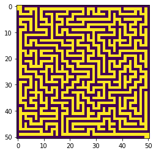

```python
gen_back(50,50)
```

Essayons maintenant sur un labyrinthe de grande taille :

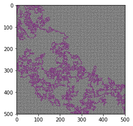

```python
dijkstra_path_full(gen_back(500,500),'big')
```

[figure not shown]

On termine avec la recherche d'une solution dans un labyrinthe inhabituel :

https://www.amazingmazes.co.uk/images/bubblebabybl.jpg

```
(700, 860)
```

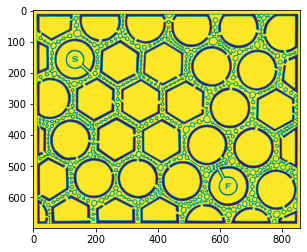

```python
import urllib.request
urllib.request.urlretrieve('https://www.amazingmazes.co.uk/images/bubblebabybl.jpg',"hives.jpg")
img = Image.open("hives.jpg").convert("L")
hives=np.array(img)
hives[hives<100]=0
hives[hives>200]=255
print(hives.shape)
plt.imshow(img)
```

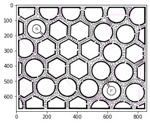

```python
path=dijkstra_path_full(hives,'hives_sol',(170,145),(550,620))
```

[figure not shown]

# References :

Génération de labyrinthes :

```
https://github.com/AryanAb/MazeGenerator

https://github.com/antigones/pymazes/blob/main/binary.py

https://github.com/ravenkls/Maze-Generator-and-Solver/blob/master/maze_generator.py
```

Algorithme de Dijkstra :

```
https://towardsdatascience.com/solving-mazes-with-python-f7a412f2493f

https://codereview.stackexchange.com/questions/249011/implementation-of-dijkstras-algorithm-in-python

https://gist.github.com/m00nlight/245d917cb030c515c513

https://fr.wikipedia.org/wiki/Algorithme_de_Dijkstra
```

Labyrinthe dessiné :

```
https://www.amazingmazes.co.uk/
```

Gauthier HARENG, étudiant de L3-Mathématiques à UGA - 2021